# hw_07

Haley Dylewski

11/9/2020

This script makes plots from the babynames data set in R package babynames, one good and two bad and explains why they are classified as such

load packages

```r
library(tidyverse)
library(babynames)
```

```r
library(plotrix)
glimpse(babynames)
```

```
## Rows: 1,924,665
## Columns: 5
## $ year <dbl> 1880, 1880, 1880, 1880, 1880, 1880, 1880, 1880, 1880, 1880, 18...
## $ sex  <chr> "F", "F", "F", "F", "F", "F", "F", "F", "F", "F", "F", "F", "F...
## $ name <chr> "Mary", "Anna", "Emma", "Elizabeth", "Minnie", "Margaret", "Id...
## $ n    <int> 7065, 2604, 2003, 1939, 1746, 1578, 1472, 1414, 1320, 1288, 12...
## $ prop <dbl> 0.07238359, 0.02667896, 0.02052149, 0.01986579, 0.01788843, 0....
```

Bad Plot

I decided to make a pie chart showing the distribution of girls names in the year 2000

```r
babies_2000 <- filter(babynames, year == 2000, sex == 'F')
glimpse(babies_2000)
```

```
## Rows: 17,653
## Columns: 5
## $ year <dbl> 2000, 2000, 2000, 2000, 2000, 2000, 2000, 2000, 2000, 2000, 20...
## $ sex  <chr> "F", "F", "F", "F", "F", "F", "F", "F", "F", "F", "F", "F", "F...
## $ name <chr> "Emily", "Hannah", "Madison", "Ashley", "Sarah", "Alexis", "Sa...
## $ n    <int> 25953, 23080, 19967, 17997, 17697, 17629, 17266, 15709, 15094,...
## $ prop <dbl> 0.01300980, 0.01156961, 0.01000912, 0.00902159, 0.00887121, 0....
```

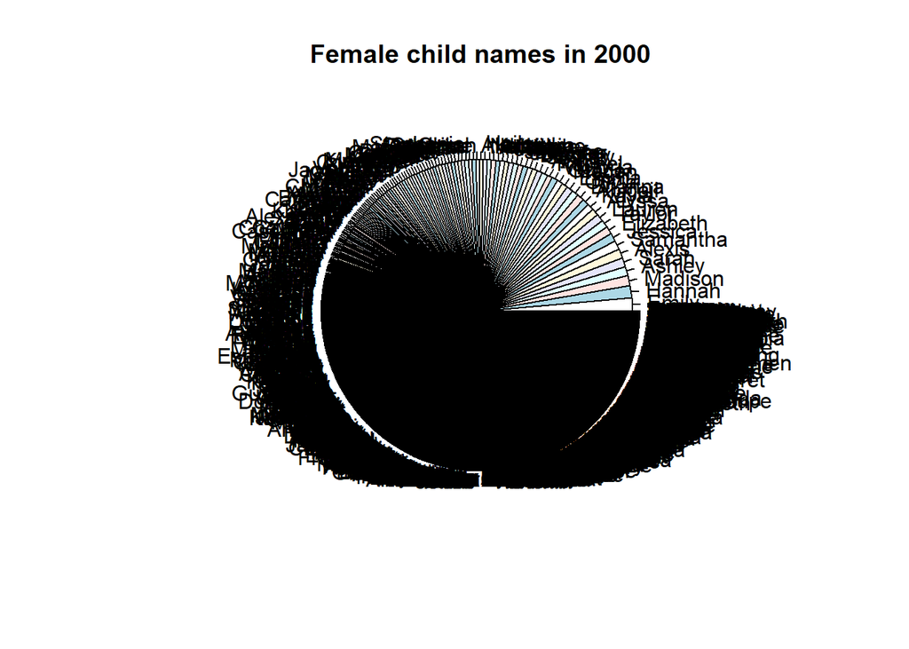

```r
total_2000 <- select(babies_2000,n) %>%
  sum()
bad_babies_data <- mutate(babies_2000, slices = (n/total_2000)*100)

bad_babies <- pie(bad_babies_data$slices, labels = bad_babies_data$name, main = "Female child names in 2000" )
```

```r
bad_babies
```

This is a literal mess, no data is visible and so does not fit the rules. So trying again, this time just looking at a single name….

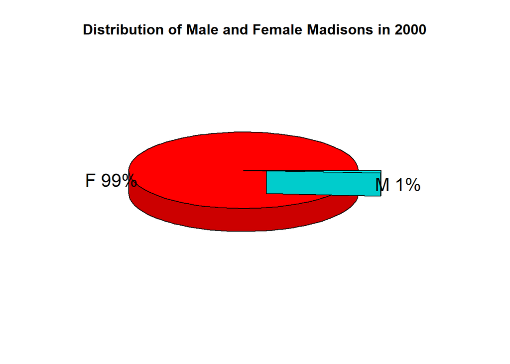

```r
madison2000 <- filter(babynames, name == 'Madison', year == 2000)
total_madison2000 <- select(madison2000, n) %>%
  sum()
bad_madison <- mutate(madison2000, mslices = round((n/total_madison2000)*100))
lbls <-paste(bad_madison$sex, bad_madison$mslices, sep = " ") %>%
  paste("%", sep = "")

bad_plot1 <- pie3D(bad_madison$mslices, labels = lbls, explode = 0.1, main = "Distribution of Male and Female Madisons in 2000")
```

This plot shows the percentage of male and female babies born named Madison in the year of 2000.

This plot is bad because: 1) It looks terrible. It doesn’t need to be 3D. The 1% area does not look like 1% 2) It is not showing anything useful. Using a pie chart here is over kill, could have been a table or literally just a sentence. Showing a pie chart of two things isn’t helpful. 3) It is not color blind friendly.

Bad plot 2: a little more complicated

```r
 bad_madison <-filter(babynames, name == 'Madison')
glimpse(bad_madison)
```

```
## Rows: 176
## Columns: 5
## $ year <dbl> 1880, 1881, 1882, 1883, 1884, 1885, 1886, 1887, 1888, 1889, 18...
## $ sex  <chr> "M", "M", "M", "M", "M", "M", "M", "M", "M", "M", "M", "M", "M...
## $ name <chr> "Madison", "Madison", "Madison", "Madison", "Madison", "Madiso...
## $ n    <int> 22, 28, 27, 22, 20, 20, 17, 18, 21, 23, 14, 20, 20, 12, 12, 15...
## $ prop <dbl> 0.00018581, 0.00025858, 0.00022126, 0.00019560, 0.00016295, 0....
```

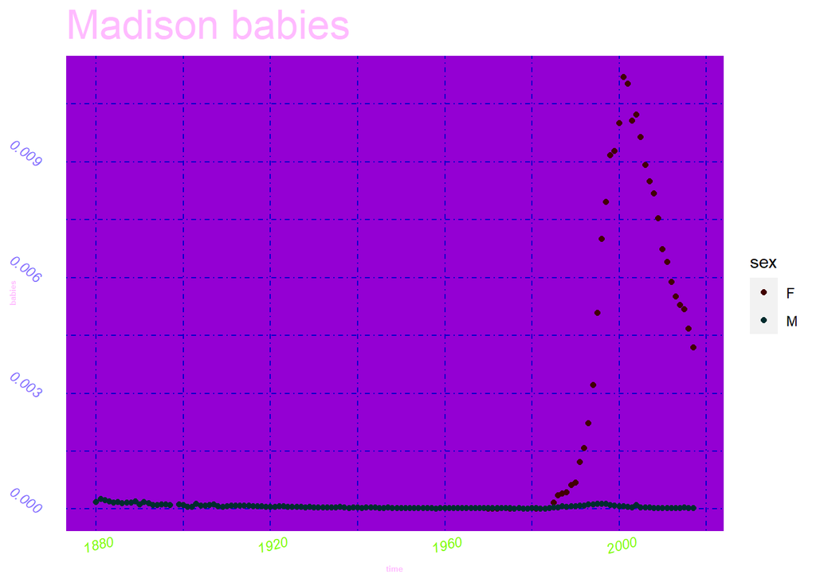

```r
badplot2 <- ggplot(bad_madison, aes(x = year, y = prop, color = sex)) +
 geom_point()+
  xlab("time") +
  ylab("babies") +
  ggtitle("Madison babies") +
  scale_color_hue(l=10, c=35)+
  theme(plot.title = element_text(color="plum1", size=25, hjust=0)) +
  theme(axis.title = element_text(color="plum1", face="bold", size=5)) +
  theme(axis.text.x = element_text(face = "italic", color =  "lawngreen", angle =15))+
    theme(axis.text.y = element_text(face = "italic", color =  "lightslateblue", angle = 325))+
  theme(
    axis.ticks = element_blank(),
    panel.background = element_rect(fill = "darkviolet", color = "darkviolet"),
    panel.grid.minor = element_line(size = 0.5, linetype = "dotdash", color = 'mediumblue'),
        panel.grid.major = element_line(size = 0.5, linetype = "dotdash", color = 'mediumblue')
    )

badplot2
```

This plot also shows the distribution of babies named Madison over time, and the relative proportion of babies named Madison that year, including both male and female.

This plot is bad because: 1) The colors are a mess. While nice i their own right, the colors make it hard to interpret what is going on. The saturation of both Male and Female colors are so close it is hard to tell the data apart. Also definitely not colorblind friendly 3) The axis titles are too small and the labels are all wack

Good Plot

The good plot shows the same relationship more clearly

```r
 good_madison <-filter(babynames, name == 'Madison')
glimpse(good_madison)
```

```
## Rows: 176
## Columns: 5
## $ year <dbl> 1880, 1881, 1882, 1883, 1884, 1885, 1886, 1887, 1888, 1889, 18...
## $ sex  <chr> "M", "M", "M", "M", "M", "M", "M", "M", "M", "M", "M", "M", "M...
## $ name <chr> "Madison", "Madison", "Madison", "Madison", "Madison", "Madiso...
## $ n    <int> 22, 28, 27, 22, 20, 20, 17, 18, 21, 23, 14, 20, 20, 12, 12, 15...
## $ prop <dbl> 0.00018581, 0.00025858, 0.00022126, 0.00019560, 0.00016295, 0....
```

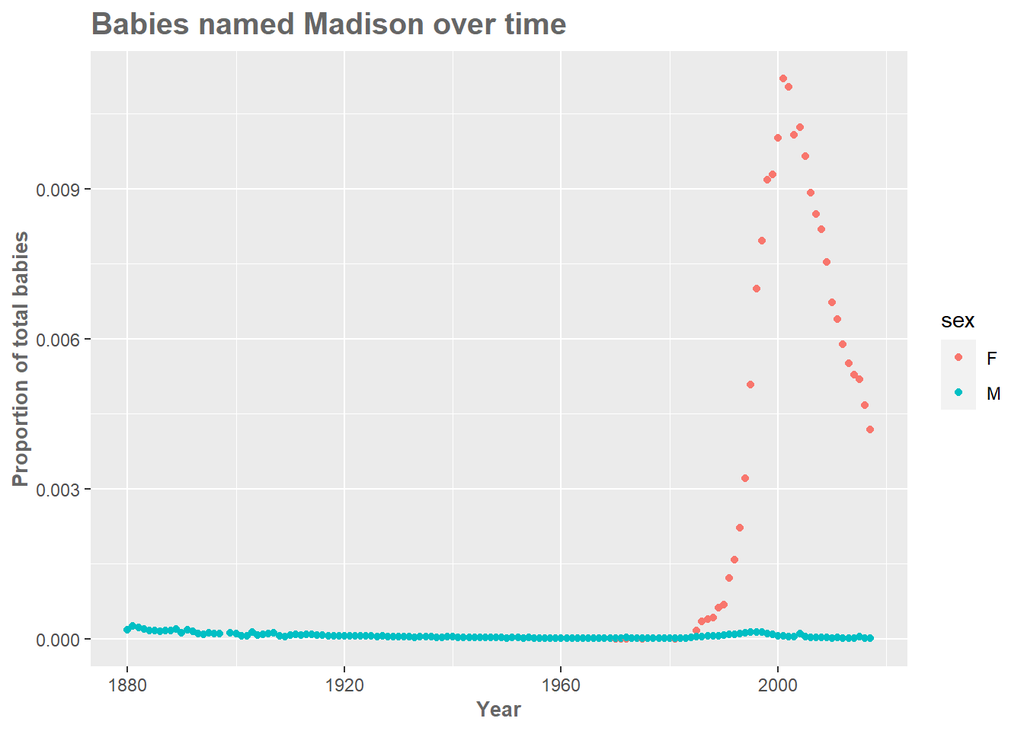

```r
goodplot <- ggplot(good_madison, aes(x = year, y = prop, color = sex)) +
  geom_point() +
  xlab("Year") +
  ylab("Proportion of total babies") +
  ggtitle("Babies named Madison over time") +
  scale_fill_discrete(name = "Gender", labels = c("Female", "Male"))+
  theme(plot.title = element_text(color="#666666", face="bold", size=15, hjust=0)) +
  theme(axis.title = element_text(color="#666666", face="bold", size=10))

goodplot
```

This plot also shows the distribution of babies named Madison over time, and the reltive proportion of babies named Madison that year, including both male and female.

This is a good plot because: 1) It shows a meaningful relationship.Here we can see the rarity of the name Madison as a boys name and that the name exploded as a girls name in the last 1900’s. Though the y-axis is in weird values, it provides us with the context of the relative popularity of the name. If we had for instance used the raw number of babies named Madison, we would have lost this clarity. 2) The text is legible and meaningful 3) The colors are descriptive 4) The graph is simple to show a simple relationship 5) The data visible

Unfortunately, this is not the best plot either. Some things that could be improved on: 1) This data should probably be further broken up into two figures. Due to the difference in magnitude between male and female. The number of males visually looks like it hovers around 0. Having a second zoomed in graph showing the male trend would be good. 2) For some reason the legend doesn’t format properly with scale_fill_discrete. 3) More axis lines could be added to improve data clarity, but I think this may clutter the graph. 4) The y-axis is in weird units. Further manipulation of the data prior to graphing could fix this. Maybe making the axis in units of 10^-3would streamline.